# [SES 5215] Assignment 3: Regression Analysis

Aeshna Prasad, Manasa Acharya, Shrinkhala Khatiwada

11/09/2021

# Introduction

Since liberalization in 1990, India has experienced an almost unmatched structural transformation in terms of a movement from an agrarian economy into services, leading to a service sector boom. Multiple studies attribute this structural change to increased internet access and penetration. However, there are other possible explanatory variables like education, increase in GNI/capita, and urbanization that could have had a positive correlation with this phenomenon. Given this, our group wishes to explore how these variables interact and the causes that could have resulted in this boom over the last three decades.

# Research Question:

- What role did internet access play in India’s service sector boom?
- What were other variables that could have explained the service sector boom?

# Sample Population:

The selected datasets study the population and economy of India. It is possible (though not necessary) that some of these datasets do not account for the informal economy, which forms a large part of the service sector in the country.

# Variables selected:

**Continuous Variables:**  
1. Value added services or VAS (PPP $)  
2. Gross National Income per capita ( $ )  
3. Population using internet (%)  
4. Urban Population (%)  
5. Mean Years of Schooling (Years)

**Categorical Variables:**  
1. Time (Years) - which is the unit of analysis  
2. Party in power each year

# Assignment 1: Loading all variables

```r
VAS <- read_xls("Directory/VAS Constant 2010 $ in India.xls", skip = 3) %>%
  filter(`Country Name` == "India") %>%
  pivot_longer(cols= 5:65, names_to = "Year", values_to = "VAS") %>%
  select(Year, VAS) %>%
  mutate(Year = as.numeric(Year))
```

```r
Urban <- read_xlsx("Directory/Urban population%.xlsx", skip = 5) %>%
  filter(Country == "India") %>%
  mutate(across(seq(5, 29, by=2), ~ as.numeric(.))) %>%
  pivot_longer(cols= seq(3, 29, by=2), names_to = "Year", values_to = "Percent_Urban_Population") %>%
  select(Year, Percent_Urban_Population) %>%
  mutate(Year = as.numeric(Year))
Urban_interp <- data.frame(approx(Urban$Year, Urban$Percent_Urban_Population, n = 30)) %>%
  rename(Year = x, Percent_Urban_Population = y)
```

```r
GNI <- read_xlsx("Directory/GNI.xlsx", skip=6) %>%
  filter(Country == "India") %>%
  mutate(across(seq(3, 61, by=2), ~ as.numeric(.))) %>%
  pivot_longer(cols= seq(3, 61, by=2), names_to = "Year", values_to = "GNI") %>%
  select(Year, GNI) %>%
  mutate(Year = as.numeric(Year))
```

```r
School <- read_xlsx("Directory/School.xlsx", skip=6) %>%
  filter(Country == "India") %>%
  mutate(across(seq(3, 61, by=2), ~ as.numeric(.))) %>%
  pivot_longer(cols= seq(3, 61, by=2), names_to = "Year", values_to = "School") %>%
  select(Year, School) %>%
  mutate(Year = as.numeric(Year))
```

```r
Internet <- read_xlsx("Directory/Internet.xlsx", skip = 3)
Internet <- Internet %>%
  filter(`Country Name` == "India") %>%
  pivot_longer(cols= 35:65, names_to = "Year", values_to = "Internet") %>%
  select(Year, Internet) %>%
  mutate(Year = as.numeric(Year))
```

```r
data <- left_join(GNI, School) %>%
  left_join(VAS) %>%
  left_join(Urban_interp) %>%
  left_join(Internet) %>%
  mutate(Party_in_Power = c(rep("Other", 1),
                           rep("INC", 5),
                           rep("Other", 2),
                           rep("BJP", 6),
                           rep("INC", 10),
                           rep("BJP", 6)))
knitr::kable(head(data))
```

[output not shown]

The total number of observations in this dataset is 30.

# Assignment 2: Descriptive Statistics

```r
GNI_t_test <- t.test(data$GNI)
School_t_test <- t.test(data$School)
VAS_t_test <- t.test(data$VAS)
Percent_Urban_Population_t_test <- t.test(data$Percent_Urban_Population)
Internet_t_test <- t.test(data$Internet)
```

```r
GNI_quartiles <- quantile(data$GNI, na.rm = TRUE)
School_quartiles <- quantile(data$School, na.rm = TRUE)
VAS_quartiles <- quantile(data$VAS, na.rm = TRUE)
Percent_Urban_Population_quartiles <- quantile(data$Percent_Urban_Population, na.rm = TRUE)
Internet_quartiles <- quantile(data$Internet, na.rm = TRUE)
```

```r
GNI_stdev <- sd(data$GNI, na.rm = TRUE)
School_stdev <- sd(data$School, na.rm = TRUE)
VAS_stdev <- sd(data$VAS, na.rm = TRUE)
Percent_Urban_Population_stdev <- sd(data$Percent_Urban_Population, na.rm = TRUE)
Internet_stdev <- sd(data$Internet, na.rm = TRUE)
```

```r
GNI_hist <- ggplot(data) +
  geom_histogram(aes(x = GNI), bins = 10, color = 'white')
School_hist <- ggplot(data) +
  geom_histogram(aes(x = School),
                 bins = 10, color = 'white')
VAS_hist <- ggplot(data) +
  geom_histogram(aes(x = VAS),
                 bins = 10, color = 'white')
Percent_Urban_Population_hist <- ggplot(data) +
  geom_histogram(aes(x = Percent_Urban_Population),
                 bins = 10, color = 'white')
Internet_hist <- ggplot(data) +
  geom_histogram(aes(x = Internet),
                 bins = 10, color = 'white')
```

### Summary table of descriptive statistics

```r
cont_summary <- tibble(
  Variable = c("VAS", "GNI",
               "Mean Years of Schooling",
               "Percent Urban Population", "Percent of population using Internet"),
  `Sample mean` = c(VAS_t_test$estimate,
                    GNI_t_test$estimate,
                    School_t_test$estimate,
                    Percent_Urban_Population_t_test$estimate,
                    Internet_t_test$estimate),
  `Population mean (95% confidence) - low` =
    c(VAS_t_test$conf.int[1],
      GNI_t_test$conf.int[1],
      School_t_test$conf.int[1],
      Percent_Urban_Population_t_test$conf.int[1],
      Internet_t_test$conf.int[1]) * 100,
  `Population mean (95% confidence) - high` =
    c(VAS_t_test$conf.int[2],
      GNI_t_test$conf.int[2],
      School_t_test$conf.int[2],
      Percent_Urban_Population_t_test$conf.int[2],
      Internet_t_test$conf.int[2]) * 100,
  Median = c(VAS_quartiles[3],
             GNI_quartiles[3],
             School_quartiles[3],
             Percent_Urban_Population_quartiles[3],
             Internet_quartiles[3] * 100),
  `Interquartile range` = c(VAS_quartiles[4] - VAS_quartiles[2],
                            GNI_quartiles[4] - GNI_quartiles[2],
                            School_quartiles[4] - School_quartiles[2],
                            Percent_Urban_Population_quartiles[4] - Percent_Urban_Population_quartiles[2],
                            (Internet_quartiles[4] - Internet_quartiles[2]) * 100),
  `Standard deviation` = c(VAS_stdev,
                          GNI_stdev,
                          School_stdev,
                          Percent_Urban_Population_stdev,
                          Internet_stdev * 1000))
kable(cont_summary, digits = 0)
```

| Variable | Sample mean | Population mean (95% confidence) - low | Population mean (95% confidence) - high | Median | Interquartile range | Standard deviation |
| --- | --- | --- | --- | --- | --- | --- |
| VAS | 614880844383 | 4.691587e+13 | 7.60603e+13 | 5.02088e+11 | 557110178266 | 3.90251e+11 |
| GNI | 3514 | 2.955430e+05 | 4.07257e+05 | 3.12300e+03 | 2210 | 1.49600e+03 |
| Mean Years of Schooling | 5 | 4.370000e+02 | 5.19000e+02 | 5.00000e+00 | 2 | 1.00000e+00 |
| Percent Urban Population | 29 | 2.839000e+03 | 3.04200e+03 | 2.90000e+01 | 4 | 3.00000e+00 |
| Percent of population using Internet | 6 | 2.960000e+02 | 9.75000e+02 | 2.18000e+02 | 1075 | 9.08900e+03 |

### Histogram table

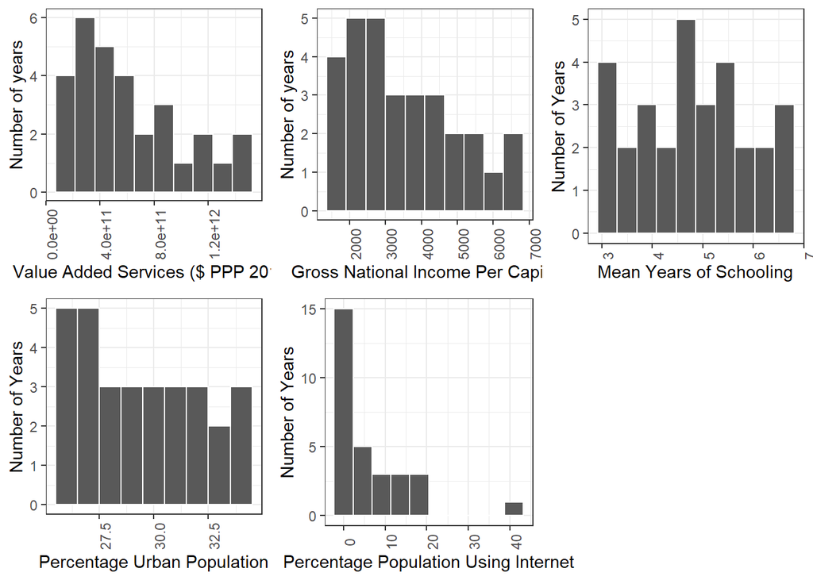

```r
pretty_VAS_hist <- VAS_hist +
  theme_bw() +
  scale_x_continuous(name = "Value Added Services ($ PPP 2010)") +
  scale_y_continuous(name = "Number of years") +
  theme(axis.text.x = element_text(angle = 90))

pretty_GNI_hist <- GNI_hist +
  theme_bw() +
  scale_x_continuous(name = "Gross National Income Per Capita") +
  scale_y_continuous(name = "Number of years") +
  theme(axis.text.x = element_text(angle = 90))

pretty_School_hist = School_hist +
  theme_bw() +
  scale_x_continuous(name = "Mean Years of Schooling") +
  scale_y_continuous(name = "Number of Years") +
  theme(axis.text.x = element_text(angle = 90))

pretty_Percent_Urban_Population_hist = Percent_Urban_Population_hist +
  theme_bw() +
  scale_x_continuous(name = "Percentage Urban Population") +
  scale_y_continuous(name = "Number of Years") +
  theme(axis.text.x = element_text(angle = 90))

pretty_Internet_hist = Internet_hist +
  theme_bw() +
  scale_x_continuous(name = "Percentage Population Using Internet") +
  scale_y_continuous(name = "Number of Years") +
  theme(axis.text.x = element_text(angle = 90))

grid.arrange(pretty_VAS_hist, pretty_GNI_hist, pretty_School_hist, pretty_Percent_Urban_Population_hist, pretty_Internet_hist,
             ncol = 3)
```

### Defining and plotting categorical Variables

```r
summary_party <- tibble(`Party in power` =
                              c("INC",
                                "BJP",
                                "Other"),
                            `Number of years in power between 1990 and 2019` =
                              c(sum(data$Party_in_Power == 'INC'),
                                sum(data$Party_in_Power == 'BJP'),
                                sum (data$Party_in_Power == 'Other')))

kable(summary_party, digits = 0)
```

| Party in power | Number of years in power between 1990 and 2019 |
| --- | --- |
| INC | 15 |
| BJP | 12 |
| Other | 3 |

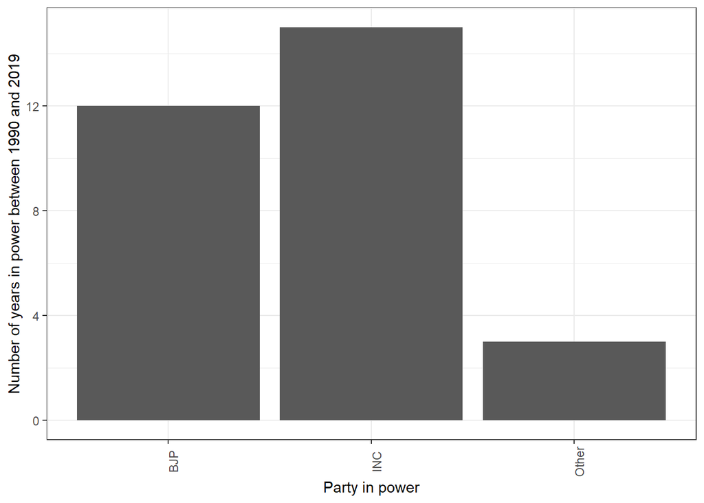

```r
ggplot(summary_party) +
  geom_bar(aes(x = `Party in power`,
               y = `Number of years in power between 1990 and 2019`),
           stat = "identity") +
  scale_y_continuous(name = "Number of years in power between 1990 and 2019",
                     breaks = c(0, 4, 8, 12, 16)) +
  theme_bw() +
  theme(axis.text.x = element_text(angle = 90))
```

# Assignment 3: Linear regression models - Relationship between VAS and other variables

### 1. Service sector and Urbanization

The regression below displays a highly statistically significant relationship between the service sector’s growth in India and the country’s urbanization, as indicated by the extremely small p-value. The relationship between the two variables in positive while the intercept is negative. The high R squared value suggests that 96% of the variance in India’s service sector can be explained by the change in percentage of population living in cities.The relationship between these two variables seems to be one of the strongest among the selected variables.

```r
Urban_lr <- lm(VAS ~ Percent_Urban_Population, data = data)

summary(Urban_lr)
```

```
##
## Call:
## lm(formula = VAS ~ Percent_Urban_Population, data = data)
##
## Residuals:
##        Min         1Q     Median         3Q        Max
## -8.613e+10 -6.147e+10 -6.242e+09  5.151e+10  1.506e+11
##
## Coefficients:
##                            Estimate Std. Error t value Pr(>|t|)
## (Intercept)              -3.531e+12  1.417e+11  -24.91   <2e-16 ***
## Percent_Urban_Population  1.410e+11  4.801e+09   29.37   <2e-16 ***
## ---
## Signif. codes:  0 '***' 0.001 '**' 0.01 '*' 0.05 '.' 0.1 ' ' 1
##
## Residual standard error: 7.042e+10 on 28 degrees of freedom
## Multiple R-squared:  0.9686, Adjusted R-squared:  0.9674
## F-statistic: 862.6 on 1 and 28 DF,  p-value: < 2.2e-16
```

### 2. Service sector and Internet

Similarly, we can observe a highly statistically significant and highly positive relationship between the service sector’s growth in India and internet coverage as well. With a p-value that is close to 0, the model suggests that we can confidently predict that 84% (i.e. R squared) of the growth of India’s service sector can be explained by the growth of proportion of population with internet. The correlation can be explained by the liberalization and globalization of India’s economy since 1991, which opened access to new services (including telecom) for Indians.

```r
Internet_lr <- lm(VAS ~ Internet, data = data)
summary(Internet_lr)
```

```
##
## Call:
## lm(formula = VAS ~ Internet, data = data)
##
## Residuals:
##        Min         1Q     Median         3Q        Max
## -5.008e+11 -9.742e+10  2.529e+10  9.253e+10  2.269e+11
##
## Coefficients:
##              Estimate Std. Error t value Pr(>|t|)
## (Intercept) 3.634e+11  3.465e+10   10.49 3.32e-11 ***
## Internet    3.955e+10  3.159e+09   12.52 5.47e-13 ***
## ---
## Signif. codes:  0 '***' 0.001 '**' 0.01 '*' 0.05 '.' 0.1 ' ' 1
##
## Residual standard error: 1.546e+11 on 28 degrees of freedom
## Multiple R-squared:  0.8484, Adjusted R-squared:  0.843
## F-statistic: 156.7 on 1 and 28 DF,  p-value: 5.474e-13
```

### 3. Service sector and Mean Years of Schooling

Additionally, a large part of the variance in the Indian service sector boom (92%) can be explained by the growth in mean years of schooling through a statistically significant positive relationship. The p-value is close to 0, as in the case of the previous regressions.

```r
School_lr <- lm(VAS ~ School, data = data)
summary(School_lr)
```

```
##
## Call:
## lm(formula = VAS ~ School, data = data)
##
## Residuals:
##        Min         1Q     Median         3Q        Max
## -1.430e+11 -9.299e+10 -1.712e+10  7.727e+10  2.853e+11
##
## Coefficients:
##               Estimate Std. Error t value Pr(>|t|)
## (Intercept) -1.012e+12  9.330e+10  -10.85 1.55e-11 ***
## School       3.401e+11  1.902e+10   17.88  < 2e-16 ***
## ---
## Signif. codes:  0 '***' 0.001 '**' 0.01 '*' 0.05 '.' 0.1 ' ' 1
##
## Residual standard error: 1.127e+11 on 28 degrees of freedom
## Multiple R-squared:  0.9195, Adjusted R-squared:  0.9166
## F-statistic: 319.6 on 1 and 28 DF,  p-value: < 2.2e-16
```

### 4. Service sector and Gross National Income Per Capita (GNI)

Furthermore, we can see a highly statistically significant and highly positive relationship between the service sector’s growth in India and GNI i.e. 99.7% which is the highest among all variables. A p-value that close to 0 implies a highly statistically significant relationship with a confidence interval of more than 99.99%.

```r
GNI_lr <- lm(VAS ~ GNI, data = data)
summary(GNI_lr)
```

```
##
## Call:
## lm(formula = VAS ~ GNI, data = data)
##
## Residuals:
##        Min         1Q     Median         3Q        Max
## -4.322e+10 -1.125e+10  1.464e+09  1.321e+10  4.410e+10
##
## Coefficients:
##               Estimate Std. Error t value Pr(>|t|)
## (Intercept) -3.006e+11  9.807e+09  -30.65   <2e-16 ***
## GNI          2.605e+08  2.575e+06  101.19   <2e-16 ***
## ---
## Signif. codes:  0 '***' 0.001 '**' 0.01 '*' 0.05 '.' 0.1 ' ' 1
##
## Residual standard error: 2.074e+10 on 28 degrees of freedom
## Multiple R-squared:  0.9973, Adjusted R-squared:  0.9972
## F-statistic: 1.024e+04 on 1 and 28 DF,  p-value: < 2.2e-16
```

### 5. Service Sector and Political Party

```r
Party_in_Power_lr <- lm(VAS ~ Party_in_Power, data = data)
summary(Party_in_Power_lr)
```

```
##
## Call:
## lm(formula = VAS ~ Party_in_Power, data = data)
##
## Residuals:
##        Min         1Q     Median         3Q        Max
## -5.062e+11 -3.264e+11  2.602e+10  2.588e+11  6.686e+11
##
## Coefficients:
##                       Estimate Std. Error t value Pr(>|t|)
## (Intercept)          8.154e+11  1.025e+11   7.953 1.51e-08 ***
## Party_in_PowerINC   -2.864e+11  1.376e+11  -2.082   0.0469 *
## Party_in_PowerOther -5.734e+11  2.293e+11  -2.501   0.0187 *
## ---
## Signif. codes:  0 '***' 0.001 '**' 0.01 '*' 0.05 '.' 0.1 ' ' 1
##
## Residual standard error: 3.552e+11 on 27 degrees of freedom
## Multiple R-squared:  0.2288, Adjusted R-squared:  0.1717
## F-statistic: 4.005 on 2 and 27 DF,  p-value: 0.02998
```

# References:

- Jim Gordon and Poonam Gupta, International Monetary Fund , “Understanding India’s Services Revolution” https://www.imf.org/external/np/apd/seminars/2003/newdelhi/gordon.pdf
- Mcinsey Global Institute, “Digital India: Technology to transform a connected nation” https://www.mckinsey.com/~/media/McKinsey/Business%20Functions/McKinsey%20Digital/Our%20Insights/Digital%20India%20Technology%20to%20transform%20a%20connected%20nation/MGI-Digital-India-Report-April-2019.pdf
- Ivan Rossignol, Parth Shri Tewari, Rosanna Chan, World Bank Blogs, “The India Paradox: Promoting Competitive Industries in a High-Growth Country” https://blogs.worldbank.org/psd/the-india-paradox-promoting-competitive-industries-in-a-high-growth-country
- United Nations Development Program Human Development Reports